# Client Report - What’s in a Name?

- Show All Code
- Hide All Code

Unit 1 Task 2

Author

Nathan McDowell

```python
import polars as pl
import numpy as np
from lets_plot import *

LetsPlot.setup_html(isolated_frame=True)
```

```python
# Learn morea about Code Cells: https://quarto.org/docs/reference/cells/cells-jupyter.html

# Include and execute your code here
df = pl.read_csv("https://posit.byui.edu/content/0d43d66f-d3b7-4c43-8c36-52e3ed69e7f1/names_year_csv.csv")
```

## QUESTION 1

**How does your name at your birth year compare to its use historically? Your must provide a chart. The years labels on your charts should not include a comma.**

I was named “Nathanael” at the height of the popularity of the name.

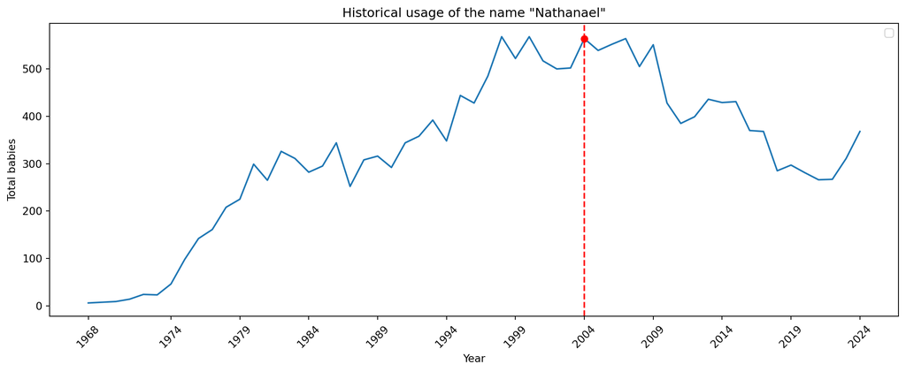

```python
# Q1
import matplotlib.pyplot as plt

my_name = "Nathanael"
my_birth_year = 2004

name_df = (
    df.filter(pl.col("name") == my_name)
      .select(["year", "Total"])
      .sort("year")
)

birth_year_total = name_df.filter(pl.col("year") == my_birth_year)["Total"][0]



years = name_df["year"].to_list()
totals = name_df["Total"].to_list()

plt.figure(figsize=(12, 5))
plt.plot(years, totals)
plt.axvline(x=my_birth_year, color="red", linestyle="--")
plt.scatter([my_birth_year], [birth_year_total], color="red", zorder=5)

plt.title(f'Historical usage of the name "{my_name}"')
plt.xlabel("Year")
plt.ylabel("Total babies")
plt.xticks(years[::5], [str(y) for y in years[::5]], rotation=45)
plt.legend()
plt.tight_layout()
plt.show()
```

## QUESTION 2

**Think of a unique name from a famous movie. Plot the usage of that name and see how changes line up with the movie release. Does it look like the movie had an effect on usage?**

Yes. There is a noticable spike at 2005, the year that Revenge of the Sith was released. Interestingly, there was a large drop in 2019, the year Rise of Skywalker released.

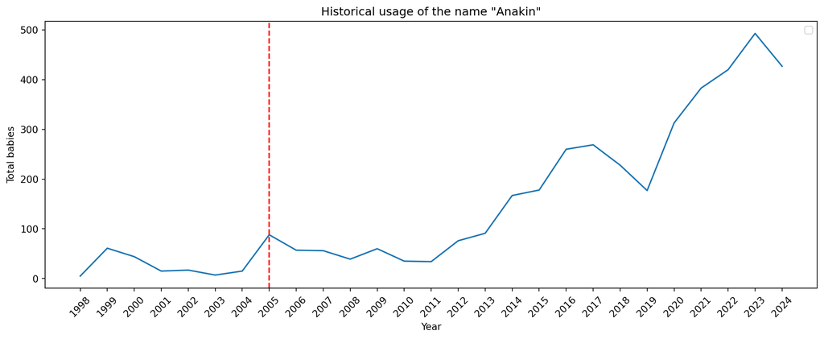

```python
# Q2
import matplotlib.pyplot as plt

name = "Anakin"
movie_year = 2005

name_df = (
    df.filter(pl.col("name") == name)
      .select(["year", "Total"])
      .sort("year")
)

years = name_df["year"].to_list()
totals = name_df["Total"].to_list()

plt.figure(figsize=(12, 5))
plt.plot(years, totals)
plt.axvline(x=movie_year, color="red", linestyle="--")

plt.title('Historical usage of the name "Anakin"')
plt.xlabel("Year")
plt.ylabel("Total babies")
plt.xticks(years, [str(y) for y in years], rotation=45)
plt.legend()
plt.tight_layout()
plt.show()
```

## QUESTION 3

**Mary, Martha, Peter, and Paul are all Christian names. From 1920 - 2000, compare the name usage of each of the four names in a single chart. What trends do you notice?**

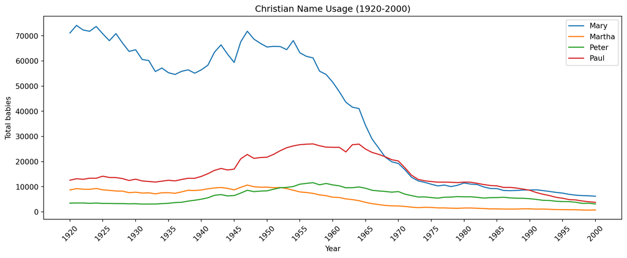

```python
# Q3
import matplotlib.pyplot as plt

names = ["Mary", "Martha", "Peter", "Paul"]

name_df = (
    df.filter(pl.col("name").is_in(names))
      .filter((pl.col("year") >= 1920) & (pl.col("year") <= 2000))
      .select(["name", "year", "Total"])
      .sort("year")
)

plt.figure(figsize=(12, 5))

for name in names:
    filtered = name_df.filter(pl.col("name") == name)
    years = filtered["year"].to_list()
    totals = filtered["Total"].to_list()
    plt.plot(years, totals, label=name)

plt.title("Christian Name Usage (1920-2000)")
plt.xlabel("Year")
plt.ylabel("Total babies")

all_years = name_df["year"].unique().sort().to_list()
plt.xticks(all_years[::5], [str(y) for y in all_years[::5]], rotation=45)

plt.legend()
plt.tight_layout()
plt.show()
```